# Ejercicios 5

#### 1 Ejercicio

El fichero oil_price.csv contiene información mensual del precio del petróleo desde el año 1985. Abre el fichero y mira el aspecto que tiene.

- La primera columna contiene el mes y el año en formato 'yyyy-mm'.
- La segunda columna contiene el precio del barril expresado en euros.
- Realiza la carga del fichero utilizando la función **read_csv** de pandas. El DataFrame creado debe tener como índices la fecha.

```python
# Sol:
import pandas as pd

datos = pd.read_csv('../datos/oil_price_monthly.csv',
                   names = ['Price'])
datos
```

|  | Price |
| --- | --- |
| 1985-05 | 36.6383 |
| 1985-06 | 35.4184 |
| 1985-07 | 34.2709 |
| 1985-08 | 33.8411 |
| 1985-09 | 34.6826 |
| 1985-10 | 33.4498 |
| 1985-11 | 34.1048 |
| 1985-12 | 29.5807 |
| 1986-01 | 25.2609 |
| 1986-02 | 16.8622 |
| 1986-03 | 13.3181 |
| 1986-04 | 12.5621 |
| 1986-05 | 14.2754 |
| 1986-06 | 12.2961 |
| 1986-07 | 10.0871 |
| 1986-08 | 13.5117 |
| 1986-09 | 13.9921 |
| 1986-10 | 13.6932 |
| 1986-11 | 14.4211 |
| 1986-12 | 15.3397 |
| 1987-01 | 16.5182 |
| 1987-02 | 15.2809 |
| 1987-03 | 15.6204 |
| 1987-04 | 15.5698 |
| 1987-05 | 15.9458 |
| 1987-06 | 16.4063 |
| 1987-07 | 17.5500 |
| 1987-08 | 17.0353 |
| 1987-09 | 16.0591 |
| 1987-10 | 16.3643 |
| ... | ... |
| 2011-03 | 82.1068 |
| 2011-04 | 85.1395 |
| 2011-05 | 79.8296 |
| 2011-06 | 79.0854 |
| 2011-07 | 81.7058 |
| 2011-08 | 76.7140 |
| 2011-09 | 79.8159 |
| 2011-10 | 78.9365 |
| 2011-11 | 81.3574 |
| 2011-12 | 81.6568 |
| 2012-01 | 86.2344 |
| 2012-02 | 89.7464 |
| 2012-03 | 94.2123 |
| 2012-04 | 91.3811 |
| 2012-05 | 86.0061 |
| 2012-06 | 76.4181 |
| 2012-07 | 83.3615 |
| 2012-08 | 90.4529 |
| 2012-09 | 87.9202 |
| 2012-10 | 85.5900 |
| 2012-11 | 84.8372 |
| 2012-12 | 82.7839 |
| 2013-01 | 84.1874 |
| 2013-02 | 86.7123 |
| 2013-03 | 84.1555 |
| 2013-04 | 79.3453 |
| 2013-05 | 79.2452 |
| 2013-06 | 78.3375 |
| 2013-07 | 81.8711 |
| 2013-08 | 82.5541 |

340 rows × 1 columns

- Determinar el mes y el año donde por primera vez el precio del petróleo superó los 40 euros, los 60 y los 80 euros.
  - Primero crea un DataFrame con el mes y el año donde por primera vez el precio del petróleo superó los 40.
  - En segundo lugar crea un DataFrame con el mes y el año donde por primera vez el precio del petróleo superó los 60.
  - En tercer lugar crea un DataFrame con el mes y el año donde por primera vez el precio del petróleo superó los 80.
  - Consulta la ayuda de la función `join`para saber cómo funciona y para qué sirve. Para ello ejecuta `pd.join?`.
  - Utiliza la función `join` para unir los datos en un unico DataFrame.

La solución es 2005-03, 2007-11, 2008-05.

```python
#Sol:
m = datos.Price >= 40
mayor40 = pd.DataFrame(datos[m].iloc[0])
```

```python
#Sol:
m = datos.Price >= 60
mayor60 = pd.DataFrame(datos[m].iloc[0])
```

```python
#Sol:
m = datos.Price >= 80
mayor80 = pd.DataFrame(datos[m].iloc[0])
```

```python
(mayor40.join(mayor60)).join(mayor80)
```

|  | 2005-03 | 2007-11 | 2008-05 |
| --- | --- | --- | --- |
| Price | 40.4137 | 62.8231 | 80.1039 |

```python
m1 = mayor40.join(mayor60)
m2 = m1.join(mayor80)
m2
```

|  | 2005-03 | 2007-11 | 2008-05 |
| --- | --- | --- | --- |
| Price | 40.4137 | 62.8231 | 80.1039 |

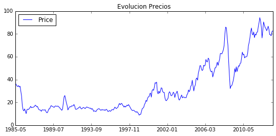

```python
# Rrepresenta gráficamente la evolución de los precios
import matplotlib as mpl
import matplotlib.pyplot as plt

%matplotlib inline

datos.plot(title = 'Evolucion Precios',
                          figsize=(9,4));                           # Tamaño de la figura
```

#### 2 Ejercicio

El fichero rotterdam_rainfall.txt recoge los datos de las precipitaciones diarias de la estación meteorológica de Rotterdam en 2012.

- La primera columna representa la fecha
- La segunda columna representa la cantidad de precipitaciones expresado en 0.1 mm (-1 si es menor a 0.05 mm).

**Notas**:

- Carga los datos en un DataFrame con la función **read_csv**
- El índice del DataFrame ha de ser la fecha
- Utiliza la opción *skiprows* para saltar las primera filas.
- Utiliza la opción _parse*dates* para parsear la fecha.

```python
# Sol
rain = pd.read_csv('../datos/rotterdam_rainfall.txt',
                  names = ['Cantidad'])
rain
```

|  | Cantidad |
| --- | --- |
| 20120101 | 207 |
| 20120102 | -1 |
| 20120103 | 144 |
| 20120104 | 36 |
| 20120105 | 84 |
| 20120106 | 8 |
| 20120107 | 30 |
| 20120108 | -1 |
| 20120109 | 8 |
| 20120110 | 0 |
| 20120111 | 10 |
| 20120112 | 9 |
| 20120113 | 4 |
| 20120114 | -1 |
| 20120115 | 0 |
| 20120116 | 0 |
| 20120117 | 0 |
| 20120118 | 32 |
| 20120119 | 144 |
| 20120120 | -1 |
| 20120121 | 35 |
| 20120122 | 19 |
| 20120123 | 16 |
| 20120124 | 5 |
| 20120125 | 5 |
| 20120126 | 33 |
| 20120127 | -1 |
| 20120128 | -1 |
| 20120129 | 0 |
| 20120130 | 1 |
| ... | ... |
| 20121202 | 93 |
| 20121203 | 52 |
| 20121204 | 96 |
| 20121205 | 29 |
| 20121206 | 7 |
| 20121207 | 107 |
| 20121208 | 1 |
| 20121209 | 102 |
| 20121210 | 16 |
| 20121211 | 2 |
| 20121212 | -1 |
| 20121213 | -1 |
| 20121214 | 103 |
| 20121215 | 8 |
| 20121216 | 24 |
| 20121217 | 31 |
| 20121218 | 16 |
| 20121219 | 0 |
| 20121220 | 68 |
| 20121221 | 9 |
| 20121222 | 224 |
| 20121223 | 76 |
| 20121224 | 32 |
| 20121225 | 125 |
| 20121226 | 45 |
| 20121227 | 27 |
| 20121228 | 18 |
| 20121229 | 2 |
| 20121230 | 23 |
| 20121231 | 50 |

366 rows × 1 columns

- Modifica los valores de la cantidad de precipitaciones a 0 cuando su valor sea -1.

```python
# Sol:
mas = rain.Cantidad == -1
rain[mas] = 0
rain
```

|  | Cantidad |
| --- | --- |
| 20120101 | 207 |
| 20120102 | 0 |
| 20120103 | 144 |
| 20120104 | 36 |
| 20120105 | 84 |
| 20120106 | 8 |
| 20120107 | 30 |
| 20120108 | 0 |
| 20120109 | 8 |
| 20120110 | 0 |
| 20120111 | 10 |
| 20120112 | 9 |
| 20120113 | 4 |
| 20120114 | 0 |
| 20120115 | 0 |
| 20120116 | 0 |
| 20120117 | 0 |
| 20120118 | 32 |
| 20120119 | 144 |
| 20120120 | 0 |
| 20120121 | 35 |
| 20120122 | 19 |
| 20120123 | 16 |
| 20120124 | 5 |
| 20120125 | 5 |
| 20120126 | 33 |
| 20120127 | 0 |
| 20120128 | 0 |
| 20120129 | 0 |
| 20120130 | 1 |
| ... | ... |
| 20121202 | 93 |
| 20121203 | 52 |
| 20121204 | 96 |
| 20121205 | 29 |
| 20121206 | 7 |
| 20121207 | 107 |
| 20121208 | 1 |
| 20121209 | 102 |
| 20121210 | 16 |
| 20121211 | 2 |
| 20121212 | 0 |
| 20121213 | 0 |
| 20121214 | 103 |
| 20121215 | 8 |
| 20121216 | 24 |
| 20121217 | 31 |
| 20121218 | 16 |
| 20121219 | 0 |
| 20121220 | 68 |
| 20121221 | 9 |
| 20121222 | 224 |
| 20121223 | 76 |
| 20121224 | 32 |
| 20121225 | 125 |
| 20121226 | 45 |
| 20121227 | 27 |
| 20121228 | 18 |
| 20121229 | 2 |
| 20121230 | 23 |
| 20121231 | 50 |

366 rows × 1 columns

- Calcula el día que ha tenido mayor cantidad de precipitación y la cantidad de precipitación

```python
# Sol:
```

#### 3 Ejercicio

El archivo WordPhones recoge información acerca del número de teléfonos en varias regiones del mundo (en miles).

- Cada columna se corresponde con una región del mundo. Las regiones son: ["N.Amer","Europe","Asia","S.Amer","Oceania","Africa","Mid.Amer"]
- Cada fila se corresponde con un año. Los años son: [1951, 1956, 1957, 1958, 1959, 1960, 1961]
- Escribir la expresión Python que recoja los datos del año 1960
  - Primero descarga el archivo WordPhones en tu directorio de trabajo.
  - Escribe la expresión Python para seleccionar la fila que se corresponde con el año 1960 (Utiliza como filtro un array de booleanos).

```python
# Sol:
```

- Ahora representa en una gráfica la evolución que ha tenido "Europe" entre los años 1956 y 1960. Ejecuta el siguiente bloque de código.

```python
# Sol:
import matplotlib.pyplot as plt
import numpy as np
%matplotlib inline
```

- Ahora representa en una gráfica la evolución que ha tenido "Europe" y "Africa" entre los años 1956 y 1960. Ejecuta el siguiente bloque de código.

```python
# Sol:
```

- Podemos representar todos los países

[figure not shown]

```python
datos.plot()

plt.xlabel('Years')
plt.ylabel('Cantidad de telefonos')
plt.title('Comparativa todas las regiones')
plt.legend(datos,loc='best');
```

## References

http://nbviewer.ipython.org/github/mbakker7/exploratory_computing_with_python/tree/master/